daili Download EN

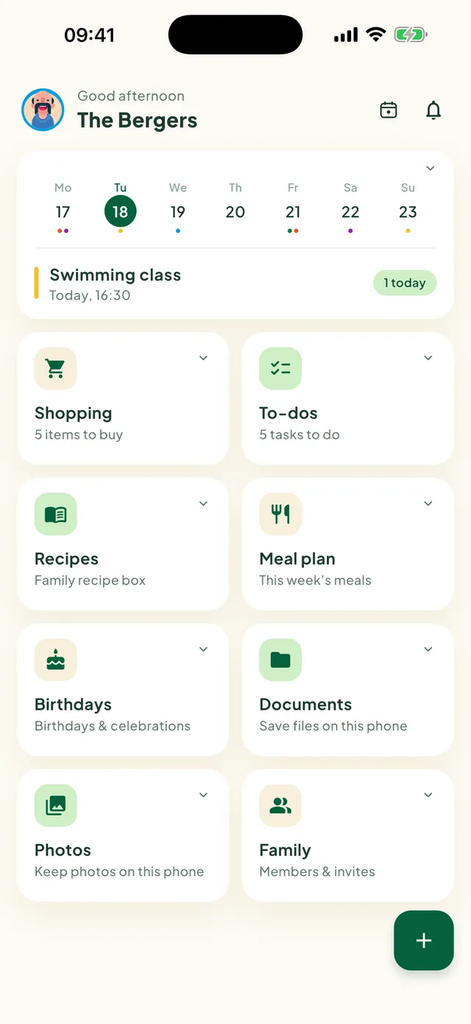

# Your family, *on the same page.*

One calm place for your family's week: a shared calendar, shopping lists and to-dos everyone can see. On every phone — and on the computer, too.

Download on the**App Store** Get it on**Google Play** Open in your browser

FreeNo adsServers in the EU

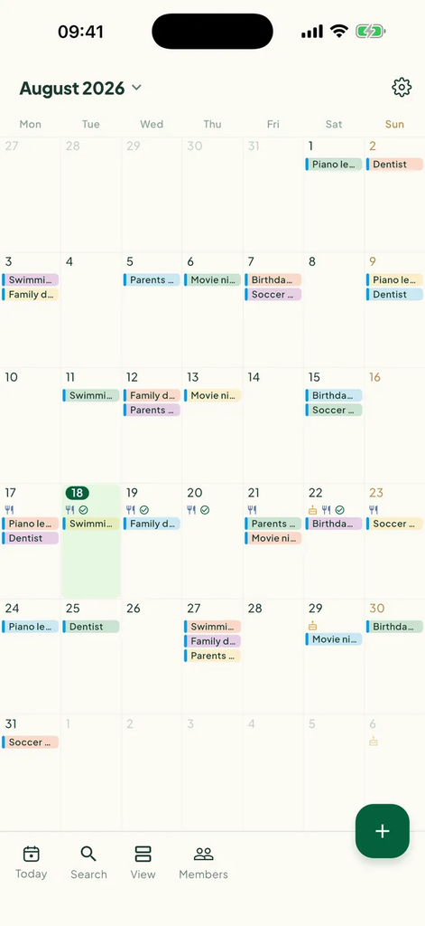

1 / 7 Calendar

## One calendar for everyone

See the whole family's week and month at a glance — and never miss pickup again.

- Color-coded events with categories, locations and notes
- Repeating events done right — soccer every Tuesday, piano every other week
- Reminders on every phone in the family
- Public holidays for 35 countries, private events stay private

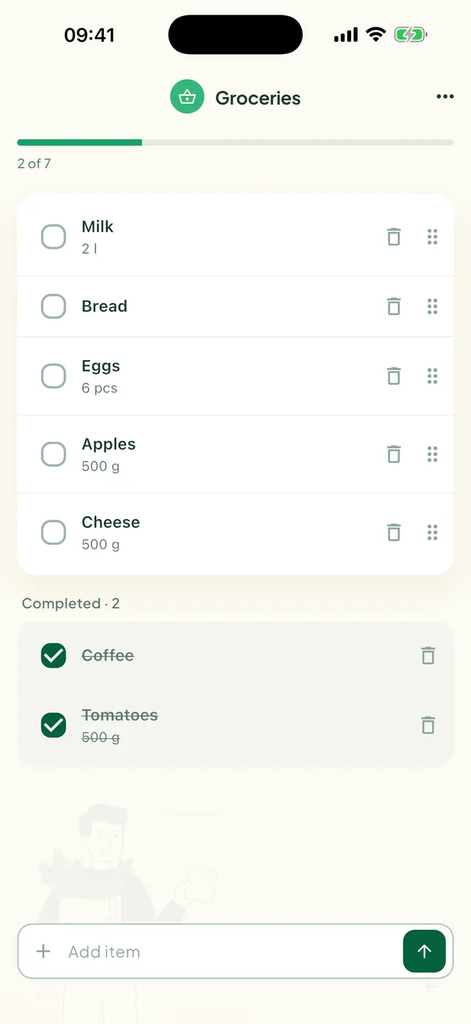

2 / 7 Shopping

## Shopping lists that update live

Add "milk" on your phone — it appears on your partner's in the store, in about a second.

- Shared lists the whole family can edit
- Quantities, categories and notes per item
- Checked items drop neatly to the bottom

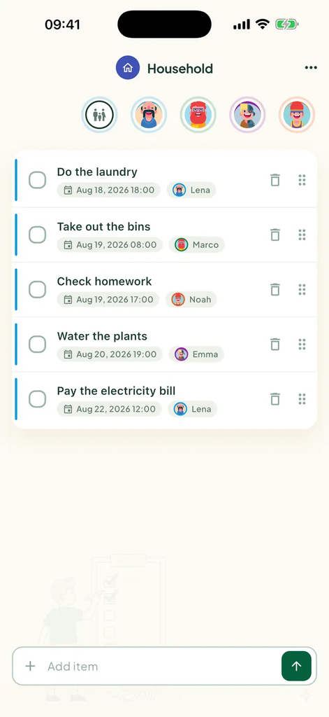

3 / 7 To-dos

## Every task has a name on it

No more "I thought you were doing it." Kids see their own tasks and can check them off.

- Assignees, due dates and reminders
- Works for chores, errands and everything between

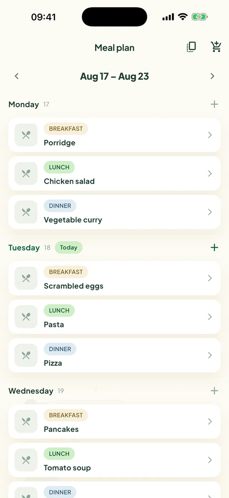

4 / 7 Meals

## Dinner, decided by Sunday

Plan breakfast to dinner for the whole week, straight from your family's own recipe box — then send the ingredients to a shopping list.

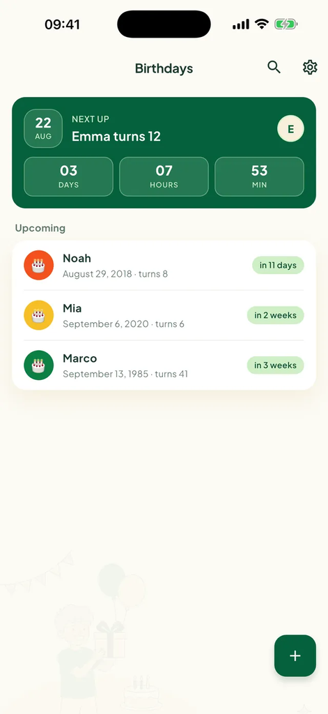

5 / 7 Celebrations

## Never miss a birthday again

Birthdays, anniversaries and family celebrations — remembered every year, with a countdown and reminders for everyone.

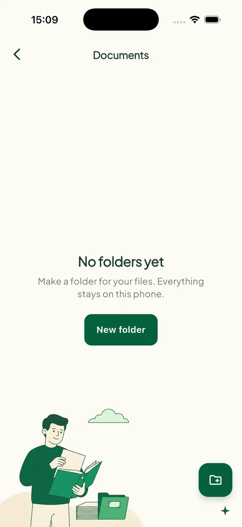

6 / 7 Private by design

## Photos & documents stay on your phone

The Daili vault keeps family photos and important documents organized — stored only on your device, never uploaded to our servers.

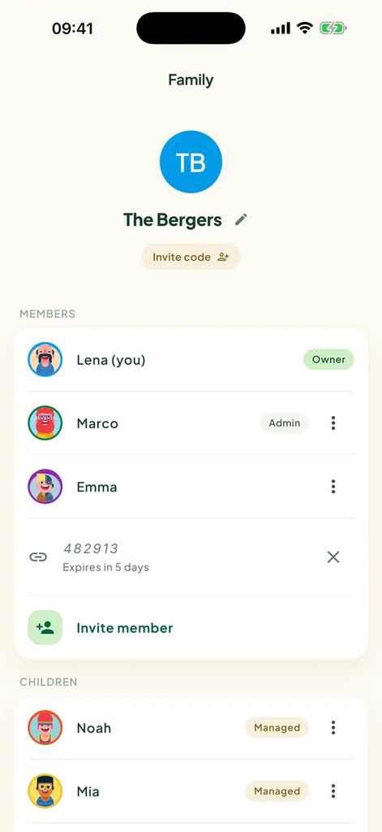

7 / 7 Family

## Parents, kids & grandma — all in

Invite your family with a simple 6-digit code or link. Parents are admins, kids and teens get their own login, and little ones without an email get a managed profile you can upgrade later.

Get Daili — free

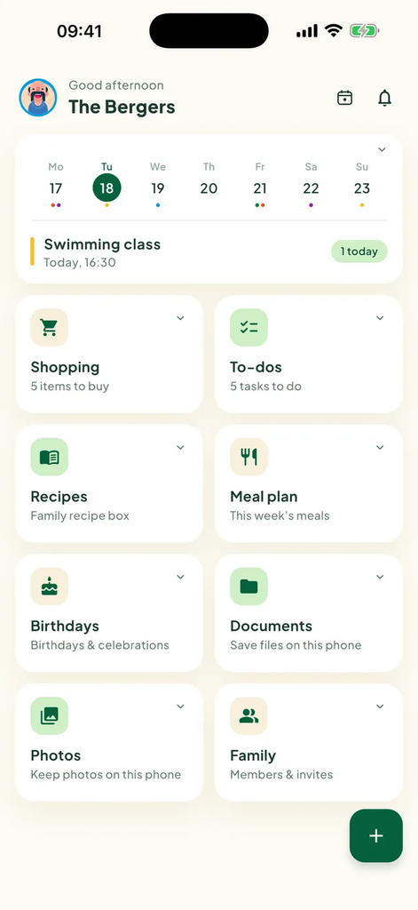

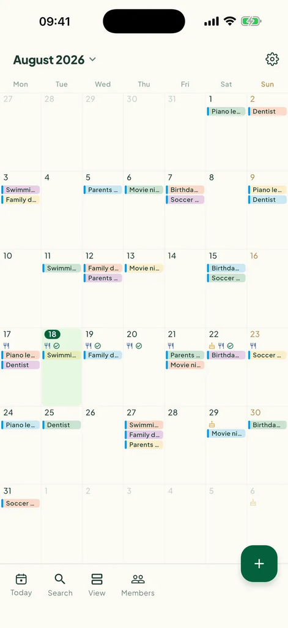

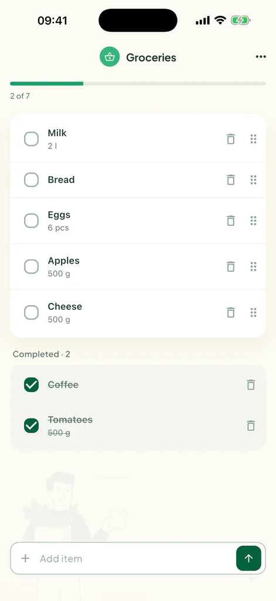

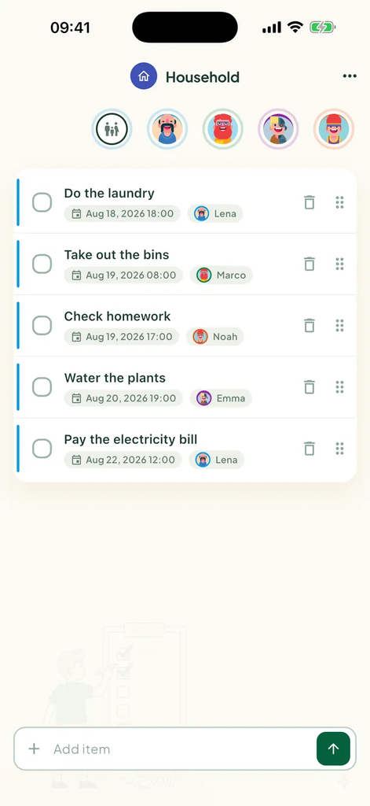

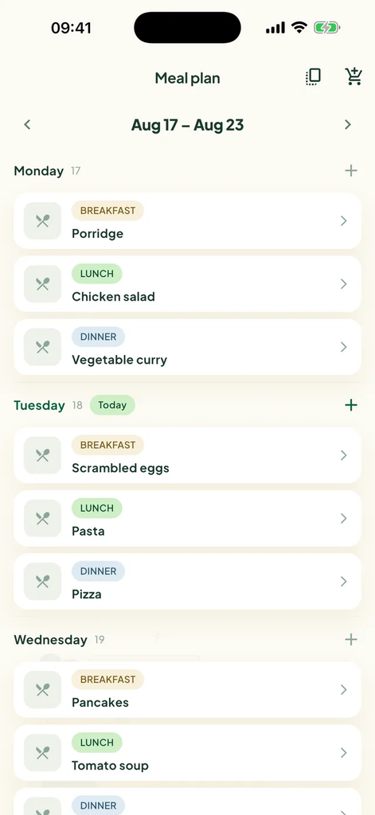

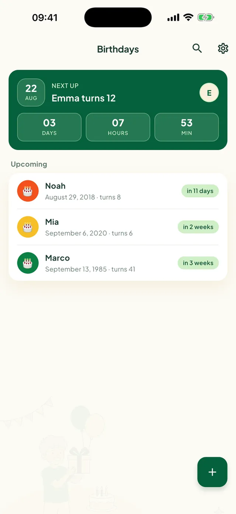

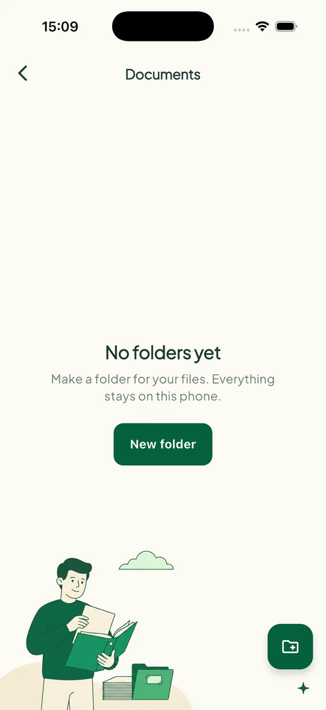

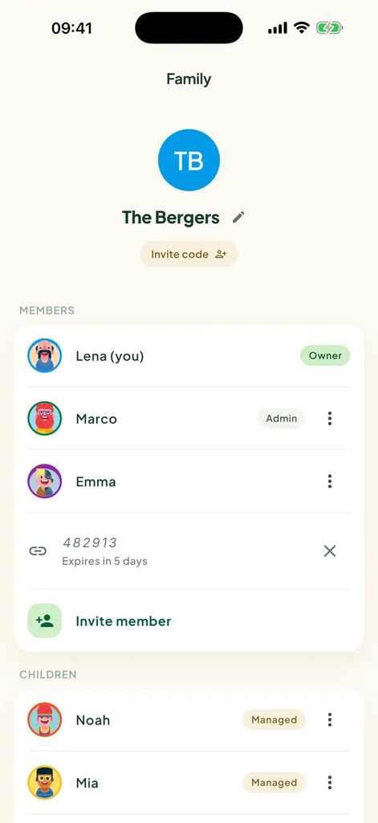

Swimming classToday · 16:30

M**Milk** · 2 lMarco is in the store

Swimming classToday · 16:30 · Emma

**Reminder on 4 phones**15 minutes before

L**Milk** · 2 lLena added it — at home

BreadMarco · in the store

synced in about a second

**Reminder**Thursday · 18:00

**6 ingredients → Groceries**added in one tap

the week, planned by Sunday

**Reminder for everyone**one week before

M**Marco** · turns 41in 3 weeks — every year

**Insurance card.pdf**on this phone only

**Holiday 2026** · 48 photosnever uploaded

no server ever sees these

LMENMi**The Bergers**5 members

**Invite code 482913**or share the link

N**Noah** · managed profileno email needed — upgrade later

app.daili.app/calendar

daili

LMENMi

**August 2026***Month**Week**Day*+ New event

Mon

Tue

Wed

Thu

Fri

Sat

Sun

*27*

*28*

*29*

*30*

*31*

*1*Summer holidays

*2*

*3*Swimming · Emma

*4*Piano · Noah

*5*

*6*Dentist · Marco

*7*Soccer · Noah

*8*Grandma visits

*9*

*10*Swimming · Emma

*11*

*12*Parents' evening

*13*

*14*Soccer · Noah

*15*Assumption Day

*16*Family lunch

*17*Swimming · Emma

*18*Piano · NoahPick-up 16:30

*19*

*20*

*21*Soccer · Noah

*22*Move-in help

*23*

*24*Swimming · Emma

*25*Piano · Noah

*26*

*27*

*28*Soccer · Noah

*30*

Web app

## Also on your computer

The same family, the same plans — in a browser window at app.daili.app. Plan the week on a big screen, add the shopping in the kitchen on your phone.

- Sign in with the same account; everything stays in sync
- Calendar, shopping lists, to-dos, recipes, meal plan, birthdays and family
- Nothing to install — works in any modern browser

Open app.daili.app

Photos and documents live only on your phone, so they are not shown in the browser. The web app is in English and German.

Getting started

## Set up in about a minute

1

### Get the app

Free on iPhone and Android — or open app.daili.app on your computer. No credit card, no trial that runs out.

2

### Create your family

Invite everyone with a 6-digit code or a link. Parents are admins, kids and teens get their own login, and little ones without an email get a managed profile.

3

### You're on the same page

Add something on your phone and it's on everyone else's in about a second — calendar, lists and to-dos alike.

Compare

## Why not just a shared calendar?

Google Calendar is very good at calendars. But family life is not only calendars — and a whiteboard in the kitchen doesn't come to the supermarket with you.

|  | Daili | Shared calendar | Paper & whiteboard |
| --- | --- | --- | --- |
| Everyone's events in one place | ✓ | ✓ | ~ |
| Reminders on every phone | ✓ | ✓ | — |
| A shopping list that updates live | ✓ | — | — |
| To-dos with a name on them | ✓ | ~ | ~ |
| Meal plan and recipe box | ✓ | — | ~ |
| Kids get their own login | ✓ | ~ | — |
| Birthdays remembered every year | ✓ | ~ | — |
| Works on the phone and in the browser | ✓ | ✓ | — |
| No ads, nothing sold | ✓ | — | ✓ |

✓ yes · ~ partly · — no

Pricing

## Free — and free for you, forever

- Every feature on this page is free right now
- No credit card, no trial period, no locked features
- If we ever add paid extras, everything that is free today stays free for you

**Our promise**Every family that joins before we add paid extras keeps everything free forever — including anything we add later.

Download on the**App Store** Get it on**Google Play**

€0per family · no catch

FAQ

## Questions, answered

**What does Daili cost?**

Nothing. Daili is free — no ads, no data selling. If we ever add paid extras, everything that is free today stays free.

**Is there a web version?**

Yes. Open app.daili.app in any browser on your computer and sign in with the same account.

**Which languages does it speak?**

The app speaks 19 languages, fully — including the reminders it sends.

**Can my kids use it?**

Yes — that's the point. Kids and teens get their own login and see their own tasks and events.

Get Daili — free →